# Lab 5

# Load Data

```r
library( dplyr )
library( scales )
library( stargazer )
library( pander )

# STARGAZER OUTPUT
#
# Use:
#
#   s.type="text"
#
# while running chunks interactively
# to see table output.
# This sets it to "html"
# when knitting the file.
s.type="html"
```

```r
URL <- "https://github.com/DS4PS/cpp-524-sum-2021/blob/main/labs/data/counterfactuals.csv?raw=true"
d <- read.csv( URL )

# set factor levels
d$group <- factor( d$group,
                   levels=c("high.ses","treatment","control"))
```

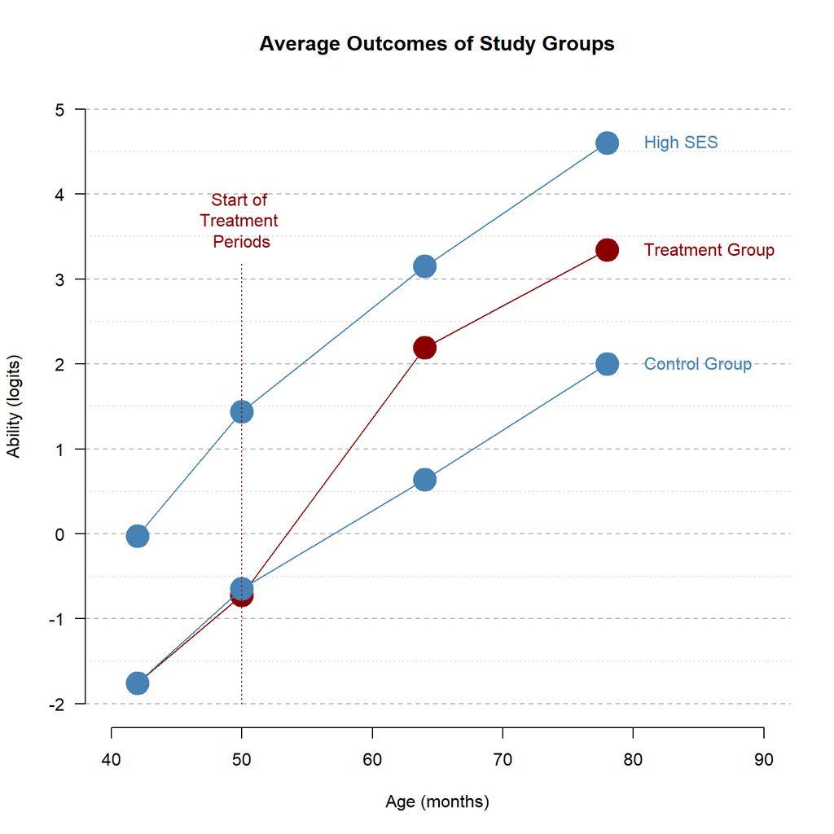

# Reflexive Pre-Post Estimator (T2-T1)

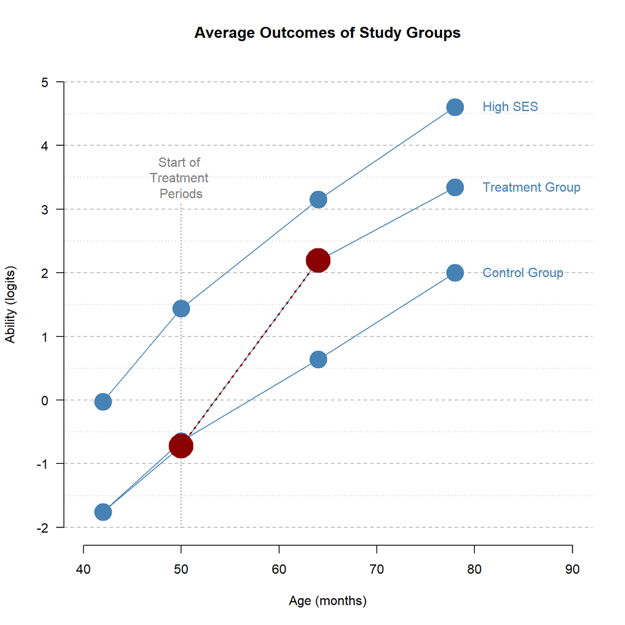

```r
dm <- filter( d,
              group %in% c("treatment") &
              time %in% c("time1","time2") )

dm$post.dummy <- ifelse( dm$time=="time2", 1, 0 )

m <- lm( ability ~ post.dummy, data=dm )

stargazer( m, type=s.type,
           omit.stat=c("f","ser","adj.rsq"),
           intercept.top=TRUE, intercept.bottom=FALSE,
           digits=2 )
```

|  | *Dependent variable:* |
| --- | --- |
|  | ability |
| Constant | -0.72*** |
|  | (0.15) |
| post.dummy | 2.91*** |
|  | (0.21) |
| Observations | 94 |
| R<sup>2</sup> | 0.67 |
| *Note:* | p<0.1; p<0.05; p<0.01 |

## Question 1a

> What is the average score for kids in the treatment group in period 1 of the study? What is the average score for the same kids in period 2?

**ANSWER:**

## Question 1b

> Explain what it means when b0 is statistically significant in the reflexive model. Explain what it means when b1 is statistically significant.

**ANSWER:**

## Question 1c

> What is the effect size according to this model?

**ANSWER:**

Test for zero trend assumption: C1=C2

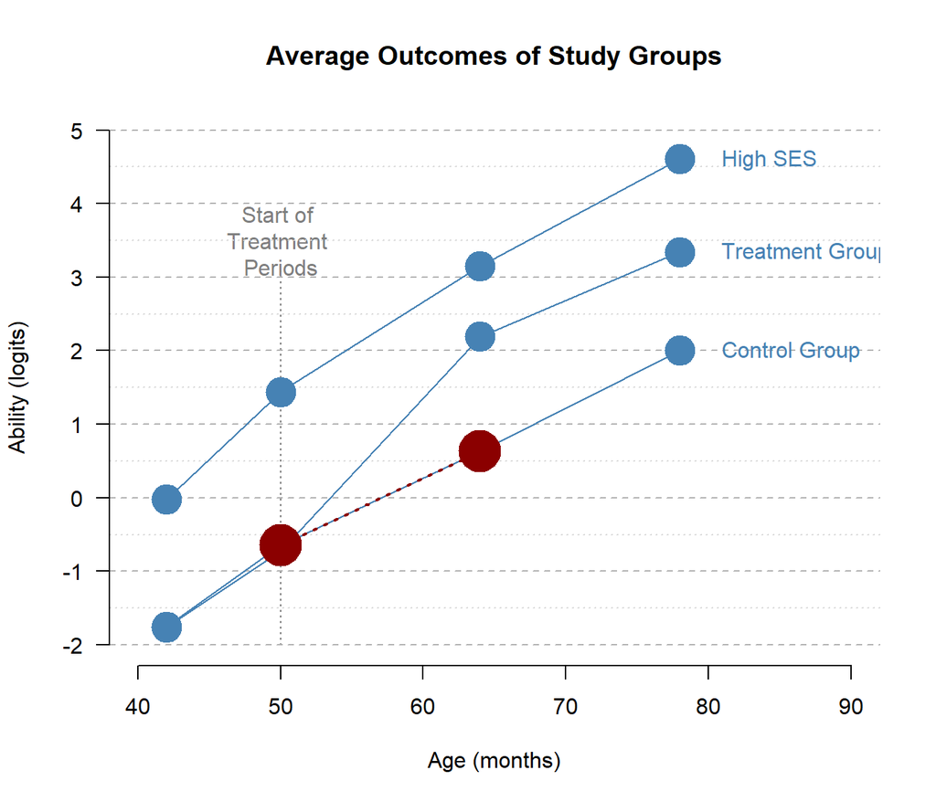

```r
dm <- filter( d,
              group %in% c("control") &
              time %in% c("time1","time2") )

dm$post.dummy <- ifelse( dm$time=="time2", 1, 0 )

m <- lm( ability ~ post.dummy, data=dm )

stargazer( m, type=s.type,
           omit.stat=c("f","ser","adj.rsq"),
           intercept.top=TRUE, intercept.bottom=FALSE,
           digits=2 )
```

|  | *Dependent variable:* |
| --- | --- |
|  | ability |
| Constant | -0.65*** |
|  | (0.12) |
| post.dummy | 1.28*** |
|  | (0.17) |
| Observations | 180 |
| R<sup>2</sup> | 0.24 |
| *Note:* | p<0.1; p<0.05; p<0.01 |

## Question 2a

> What is the average score for kids in the control group in period 1 of the study? What is the average score for the same kids in period 2?

**ANSWER:**

## Question 2b

> Which coefficient represents the test for whether we observe a secular trend in student achievement gains independent of the treatment? What is the decision rule?

**ANSWER:**

## Question 2c

> What does this model tell us about the appropriateness of the reflexive model?

**ANSWER:**

# Post-Test Only Estimator (T2-C2)

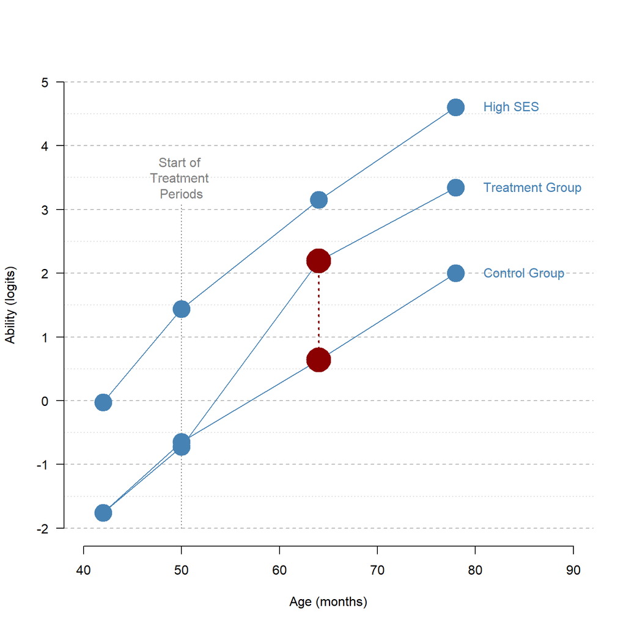

```r
dm <- filter( d,
              group %in% c("treatment","control") &
              time=="time2" )

dm$treat.dummy <- ifelse( dm$group=="treatment", 1, 0 )

m <- lm( ability ~ treat.dummy, data=dm )

stargazer( m, type=s.type,
           omit.stat=c("f","ser","adj.rsq"),
           intercept.top=TRUE, intercept.bottom=FALSE,
           digits=2 )
```

|  | *Dependent variable:* |
| --- | --- |
|  | ability |
| Constant | 0.64*** |
|  | (0.12) |
| treat.dummy | 1.55*** |
|  | (0.20) |
| Observations | 137 |
| R<sup>2</sup> | 0.31 |
| *Note:* | p<0.1; p<0.05; p<0.01 |

## Question 3a

> What is the average score for kids in the control group in the study? What is the average score for the kids in the treatment group?

**ANSWER:**

## Question 3b

> What is the effect size identified by the model?

## Question 3c

> What is the identifying assumption of this model? Or stated differently, what must be true in order for the post-test only estimator to be appropriate?

**ANSWER:**

## Question 3d

> According to the model below is the assumption met? How can you tell?

**ANSWER:**

```r
dm <- filter( d,
              group %in% c("treatment","control") &
              time=="time1" )

dm$treat.dummy <- ifelse( dm$group=="treatment", 1, 0 )

m <- lm( ability ~ treat.dummy, data=dm )

stargazer( m, type=s.type,
           omit.stat=c("f","ser","adj.rsq"),
           intercept.top=TRUE, intercept.bottom=FALSE,
           digits=2 )
```

|  | *Dependent variable:* |
| --- | --- |
|  | ability |
| Constant | -0.65*** |
|  | (0.12) |
| treat.dummy | -0.07 |
|  | (0.20) |
| Observations | 137 |
| R<sup>2</sup> | 0.001 |
| *Note:* | p<0.1; p<0.05; p<0.01 |

# Diff-in-Diff Estimator [ gains - trend ]

Total Gains: T2-T1  
Trend: C2-C1  
DID Estimator: [ gains - trend ] = [ (T2-T1) - (C2-C1) ]

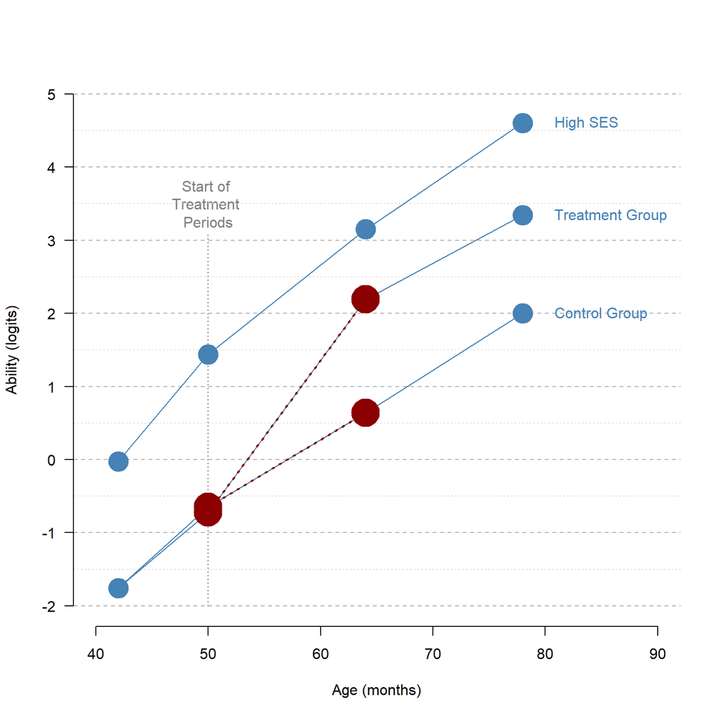

```r
dm <- filter( d, group %in% c("treatment","control") &
                time %in% c("time1","time2") )

dm$treat.dummy <- ifelse( dm$group=="treatment", 1, 0 )
dm$post.dummy  <- ifelse( dm$time=="time2", 1, 0 )

dm$treat.post.dummy <- dm$treat.dummy * dm$post.dummy

m <- lm( ability ~ treat.dummy + post.dummy + treat.post.dummy,
         data=dm)

stargazer( m, type=s.type,
           omit.stat=c("f","ser","adj.rsq"),
           intercept.top=TRUE, intercept.bottom=FALSE,
           digits=2 )
```

|  | *Dependent variable:* |
| --- | --- |
|  | ability |
| Constant | -0.65*** |
|  | (0.12) |
| treat.dummy | -0.07 |
|  | (0.20) |
| post.dummy | 1.28*** |
|  | (0.16) |
| treat.post.dummy | 1.63*** |
|  | (0.28) |
| Observations | 274 |
| R<sup>2</sup> | 0.48 |
| *Note:* | p<0.1; p<0.05; p<0.01 |

```r
b0 <- m$coefficients[1] %>% as.numeric() %>% round(2)
b1 <- m$coefficients[2] %>% as.numeric() %>% round(2)
b2 <- m$coefficients[3] %>% as.numeric() %>% round(2)
b3 <- m$coefficients[4] %>% as.numeric() %>% round(2)

b0                 # C1
```

```
## [1] -0.65
```

```r
b0 + b1            # T1
```

```
## [1] -0.72
```

```r
b0 + b2            # C2
```

```
## [1] 0.63
```

```r
b0 + b1 + b2 + b3  # T2
```

```
## [1] 2.19
```

```r
b0 + b1 + b2       # CF
```

```
## [1] 0.56
```

```r
CF <- b0 + b1 + b2
T2 <- b0 + b1 + b2 + b3
T2-CF
```

```
## [1] 1.63
```

## Question 4a

> Are the treatment and control groups equivalent prior to the intervention? How do you know?

**ANSWER:**

## Question 4b

> Do we observe secular trends (gains independent of the treatment)? How do you know?

**ANSWER:**

## Question 4c

> What is the effect size in this model (gains from the treatment)?

**ANSWER:**

## Question 4d

> What does statistical significance of b3 represent? In other words, which contrast is being tested?

**ANSWER:**

## Question 5a

> Do the reflexive and diff-in-diff models generate the same results (approximately)? Why?

**ANSWER:**

## Question 5b

> Do the post-test only and diff-in-diff models generate the same results (approximately)? Why?

**ANSWER:**

# Alternative Diff-in-Diff Estimator

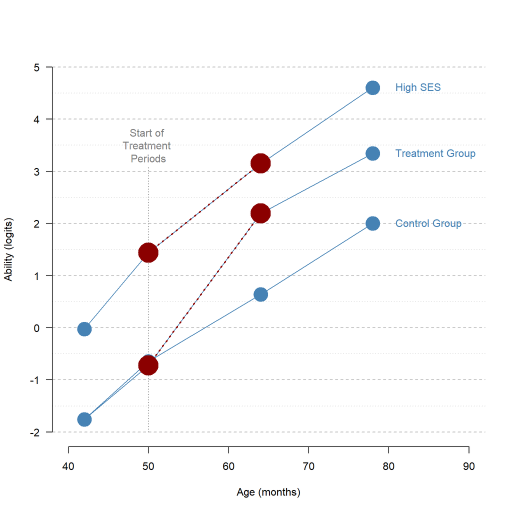

```r
dm <- filter( d, group %in% c("treatment","high.ses") &
                time %in% c("time1","time2") )

dm$treat.dummy <- ifelse( dm$group=="treatment", 1, 0 )
dm$pre.dummy   <- ifelse( dm$time=="time1", 1, 0 )
dm$post.dummy  <- ifelse( dm$time=="time2", 1, 0 )

dm$treat.post.dummy <- dm$treat.dummy * dm$post.dummy

m <- lm( ability ~ treat.dummy + post.dummy + treat.post.dummy,
         data=dm)

stargazer( m, type=s.type,
           omit.stat=c("f","ser","adj.rsq"),
           intercept.top=TRUE, intercept.bottom=FALSE,
           digits=2 )
```

|  | *Dependent variable:* |
| --- | --- |
|  | ability |
| Constant | 1.44*** |
|  | (0.19) |
| treat.dummy | -2.16*** |
|  | (0.24) |
| post.dummy | 1.71*** |
|  | (0.27) |
| treat.post.dummy | 1.20*** |
|  | (0.34) |
| Observations | 150 |
| R<sup>2</sup> | 0.68 |
| *Note:* | p<0.1; p<0.05; p<0.01 |

## Question 6a

> Are the pre-treatment differences (C1=T1?) different in this model versus the previous diff-in-diff? Why or why not?

**ANSWER:**

## Question 6b

> Does the diff-in-diff model require that study groups are equivalent prior to treatment to generate valid results?

**ANSWER:**

## Question 6c

> Is the secular trend identified by this model different from the previous diff-in-diff (approximately)? Why or why not?

**ANSWER:**

**ANSWER:**

## Question 6e

> What is the identification assumption of the diff-in-diff model?

**ANSWER:**

# Parallel Lines Test

Does the high SES group model secular trend appropriately?

Test: are the study group trend lines parallel prior to the intervention?

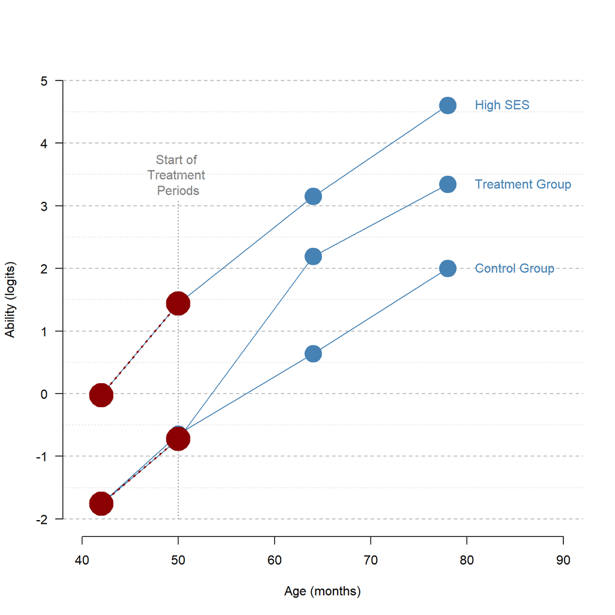

```r
dm <- filter( d, group %in% c("treatment","high.ses") &
                time %in% c("time0","time1") )

dm$treat.dummy <- ifelse( dm$group=="treatment", 1, 0 )
dm$pre.dummy   <- ifelse( dm$time=="time0", 1, 0 )
dm$post.dummy  <- ifelse( dm$time=="time1", 1, 0 )

dm$treat.post <- dm$treat.dummy * dm$post.dummy

m <- lm( ability ~ treat.dummy + post.dummy + treat.post,
         data=dm)

stargazer( m, type=s.type,
           omit.stat=c("f","ser","adj.rsq"),
           intercept.top=TRUE, intercept.bottom=FALSE,
           digits=2 )
```

|  | *Dependent variable:* |
| --- | --- |
|  | ability |
| Constant | -0.02 |
|  | (0.21) |
| treat.dummy | -1.73*** |
|  | (0.27) |
| post.dummy | 1.46*** |
|  | (0.30) |
| treat.post | -0.43 |
|  | (0.38) |
| Observations | 150 |
| R<sup>2</sup> | 0.51 |
| *Note:* | p<0.1; p<0.05; p<0.01 |

Does the control group model secular trend appropriately?

Test: are the study group trend lines parallel prior to the intervention?

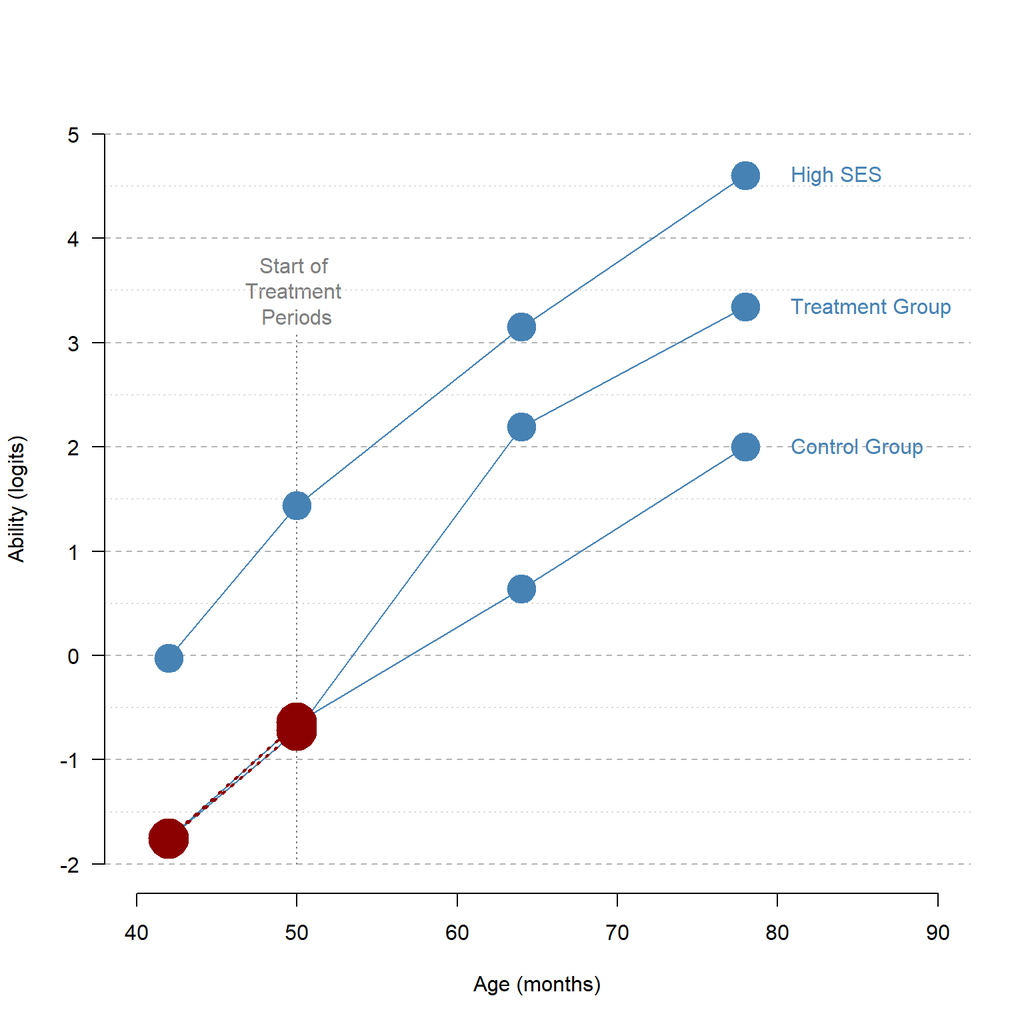

```r
dm <- filter( d, group %in% c("treatment","control") &
                time %in% c("time0","time1") )

dm$treat.dummy <- ifelse( dm$group=="treatment", 1, 0 )
dm$post.dummy  <- ifelse( dm$time=="time1", 1, 0 )

dm$treat.post <- dm$treat.dummy * dm$post.dummy

m <- lm( ability ~ treat.dummy + post.dummy + treat.post,
         data=dm)

stargazer( m, type=s.type,
           omit.stat=c("f","ser","adj.rsq"),
           intercept.top=TRUE, intercept.bottom=FALSE,
           digits=2 )
```

|  | *Dependent variable:* |
| --- | --- |
|  | ability |
| Constant | -1.76*** |
|  | (0.12) |
| treat.dummy | 0.001 |
|  | (0.21) |
| post.dummy | 1.11*** |
|  | (0.17) |
| treat.post | -0.08 |
|  | (0.29) |
| Observations | 274 |
| R<sup>2</sup> | 0.18 |
| *Note:* | p<0.1; p<0.05; p<0.01 |

## Question 7

> Which coefficient captures the parallel lines test? Do we want it to be significant or not?

**ANSWER:**